# Part 1: Data Preprocessing

# Appendix

## Codes

```r
knitr::opts_chunk$set(echo = TRUE)
library(dplyr)
library(tidyr)
library(readr)
library(magrittr)
library(ggplot2)
library(knitr)
library(pastecs)
library(boot)
library(ggm)

detect_outlier <- function(x) {

  Quantile1 <- quantile(x, probs=.25, na.rm = TRUE)
  Quantile3 <- quantile(x, probs=.75, na.rm = TRUE)
  IQR = Quantile3-Quantile1
  x > Quantile3 + (IQR*1.5) | x < Quantile1 - (IQR*1.5)
}

# Takes a data frame and a column and removes the outliers from the
# original data frame
remove_outlier <- function(dataframe,
                           columns=names(dataframe)) {
  # for loop to traverse in columns vector
  for (colmn in columns) {
    # remove observation if it satisfies outlier function
    dataframe <- dataframe[!detect_outlier(dataframe[[colmn]]), ]
  }
  return(dataframe)
}
df_main <- read_csv(file="Data Carrard et al. 2022 MedTeach.csv",
                    show_col_types=FALSE)

# Let's first take a look at the data
head(df_main)
```

```
## # A tibble: 6 × 20
##      id   age  year   sex glang  part   job stud_h health  psyt  jspe qcae_cog
##   <dbl> <dbl> <dbl> <dbl> <dbl> <dbl> <dbl>  <dbl>  <dbl> <dbl> <dbl>    <dbl>
## 1     2    18     1     1   120     1     0     56      3     0    88       62
## 2     4    26     4     1     1     1     0     20      4     0   109       55
## 3     9    21     3     2     1     0     0     36      3     0   106       64
## 4    10    21     2     2     1     0     1     51      5     0   101       52
## 5    13    21     3     1     1     1     0     22      4     0   102       58
## 6    14    26     5     2     1     1     1     10      2     0   102       48
## # … with 8 more variables: qcae_aff <dbl>, amsp <dbl>, erec_mean <dbl>,
## #   cesd <dbl>, stai_t <dbl>, mbi_ex <dbl>, mbi_cy <dbl>, mbi_ea <dbl>
```

```r
# column number of the data of different types are separated
intervals <- c(2, 3, 8, 11:20)
nominals <- c(4, 5)
ordinals <- c(9)
binaries <- c(6, 7, 10)

cnames <- names(df_main)

# We can visualized mbi_ex vs. qcae_aff to visually explore their relationship
sum(is.na.data.frame(df_main))
```

```
## [1] 0
```

```r
# Binary data are all 1 or 0
table(df_main[binaries])
```

```
## , , psyt = 0
##
##     job
## part   0   1
##    0 212  93
##    1 246 136
##
## , , psyt = 1
##
##     job
## part   0   1
##    0  50  32
##    1  69  48
```

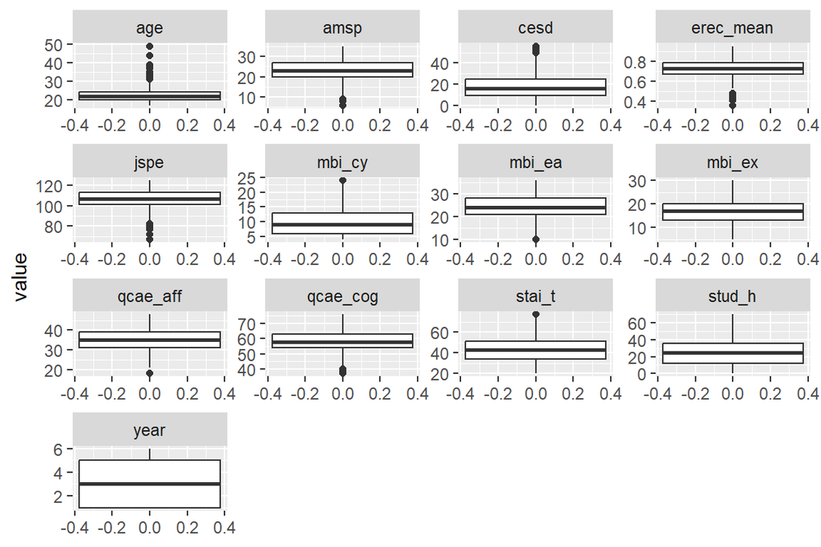

```r
# Plotting outliers for interval data
df_main %>%
  pivot_longer(cols=cnames[intervals], names_to="colname", values_to="value") %>%
  ggplot() +
  geom_boxplot(aes(y=value)) +
  facet_wrap(vars(colname), scales="free")
```

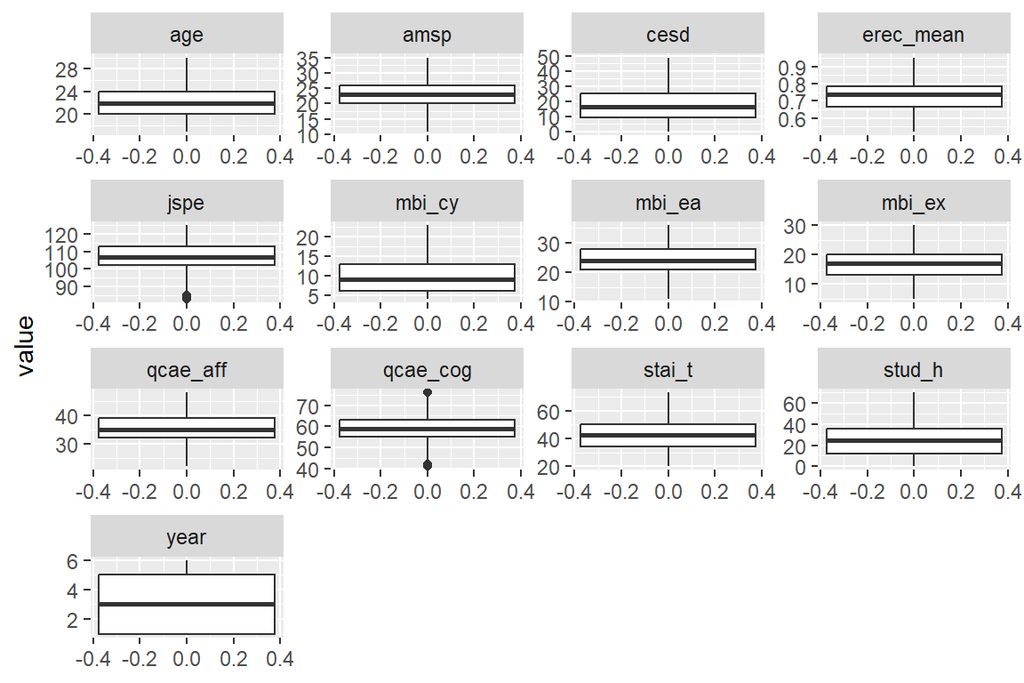

```r
# Outliers of interval data are removed
df_main %<>%
  remove_outlier(columns=cnames[intervals])
# Plotting outliers for interval data after removal
df_main %>%
  pivot_longer(cols=cnames[intervals], names_to="colname", values_to="value") %>%
  ggplot() +
  geom_boxplot(aes(y=value)) +
  facet_wrap(vars(colname), scales="free")
```

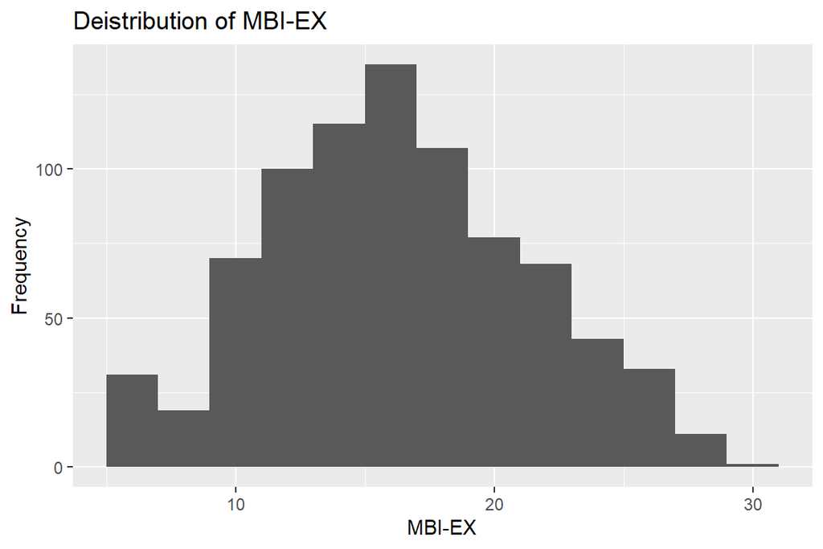

```r
# As an initial evalutation of association between data, the correlation matrix of interval data are calculated using Pearson's method

initcor <- cor(x=df_main[intervals], use="complete.obs", method="pearson")

df_focus <- df_main %>% select(mbi_ex, cesd)

stat_mbi_ex <- stat.desc(df_focus$mbi_ex, norm=TRUE)
stat_cesd <- stat.desc(df_focus$cesd, norm=TRUE)


# First histogram and qq normal plot are generated to explore the overal
# distribution and normality of the data.
ggplot(df_focus) +
  geom_histogram(aes(x=mbi_ex),binwidth=2) +
  labs(x="MBI-EX", y="Frequency", title="Deistribution of MBI-EX")
```

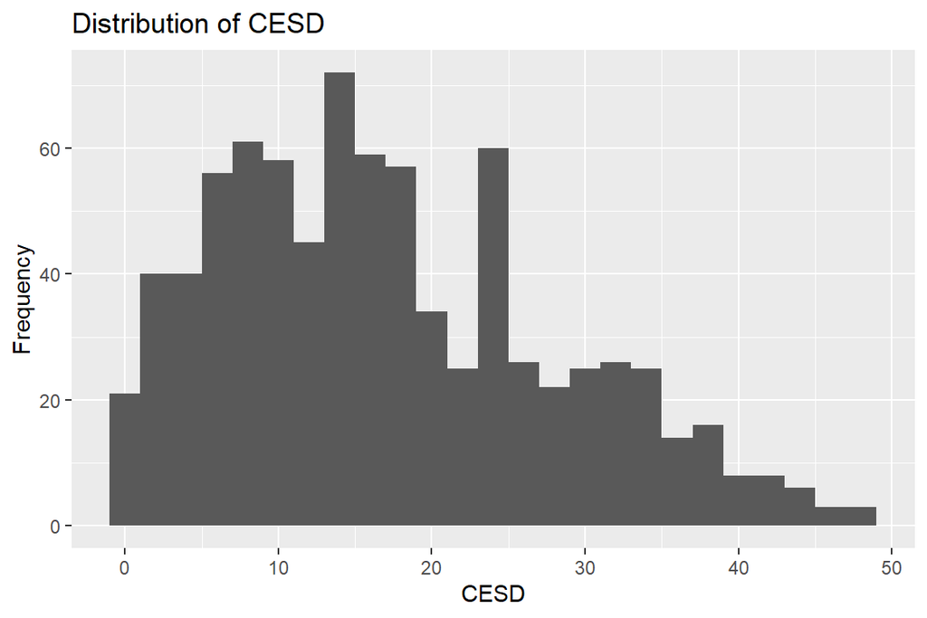

```r
ggplot(df_focus) +
  geom_histogram(aes(x=cesd),binwidth=2) +
  labs(x="CESD", y="Frequency", title="Distribution of CESD")
```

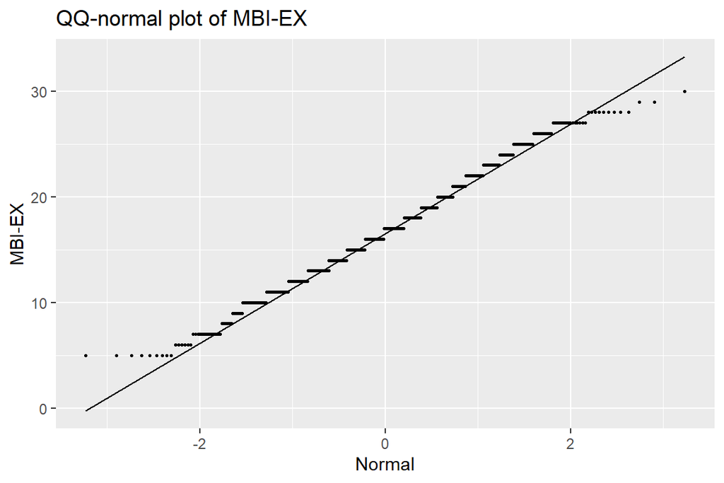

```r
ggplot(df_focus) +
  geom_qq(aes(sample=mbi_ex), size=0.5) +
  stat_qq_line(aes(sample=mbi_ex)) +
  labs(x="Normal", y="MBI-EX", title="QQ-normal plot of MBI-EX")
```

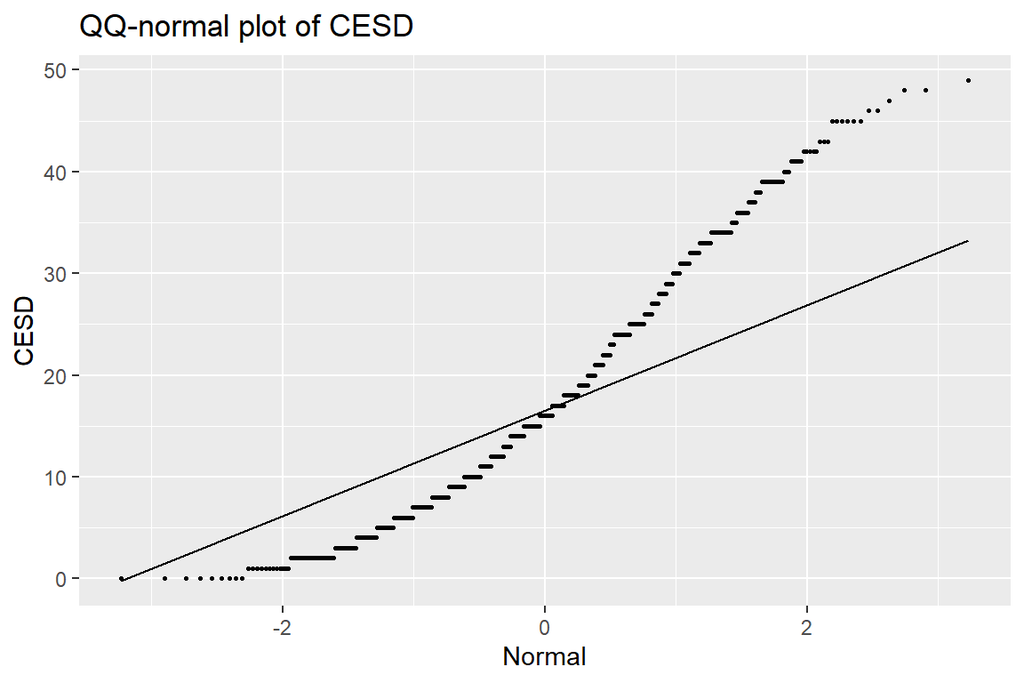

```r
ggplot(df_focus) +
  geom_qq(aes(sample=cesd), size=0.5) +
  stat_qq_line(aes(sample=mbi_ex)) +
  labs(x="Normal", y="CESD", title="QQ-normal plot of CESD")
```

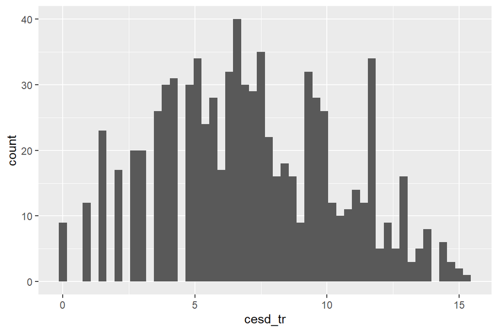

```r
# A test of normality is performed first.
stat_mbi_ex <- stat.desc(df_focus$mbi_ex, norm=TRUE)
stat_cesd <- stat.desc(df_focus$cesd, norm=TRUE)


# Tranformation function
tr <- function(x)x^0.7
tr_inv <- function(y)y^(10/7)

# Transforming data to improve normality
df_focus_tr <- df_focus %>%
  mutate(cesd_tr=tr(cesd), mbi_ex_tr=tr(mbi_ex))

df_focus_tr %>%
  ggplot() +
  geom_histogram(aes(x=cesd_tr), binwidth=0.3)
```

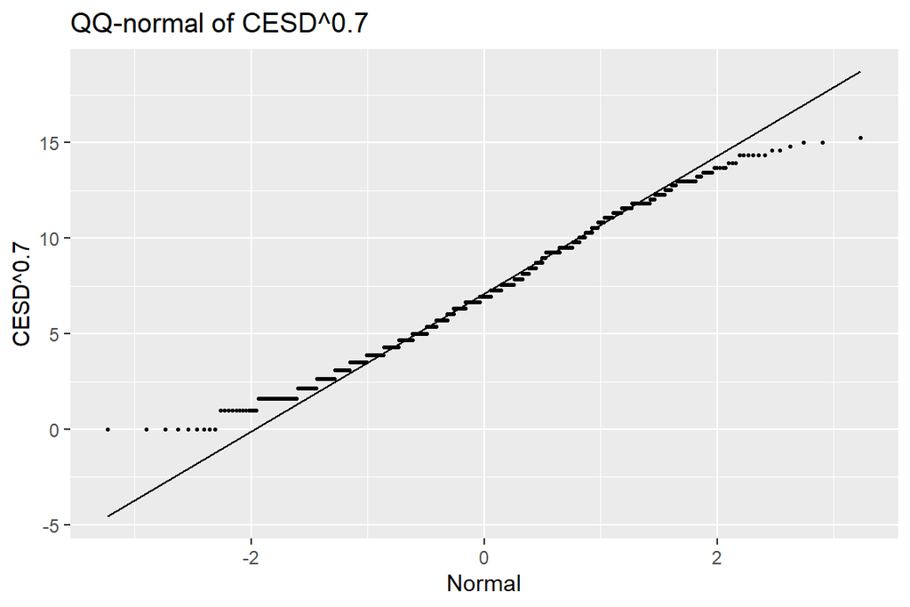

```r
ggplot(df_focus_tr) +
  geom_qq(aes(sample=cesd_tr), size=0.5) +
  stat_qq_line(aes(sample=cesd_tr)) +
  labs(x="Normal", y="CESD^0.7", title="QQ-normal of CESD^0.7")
```

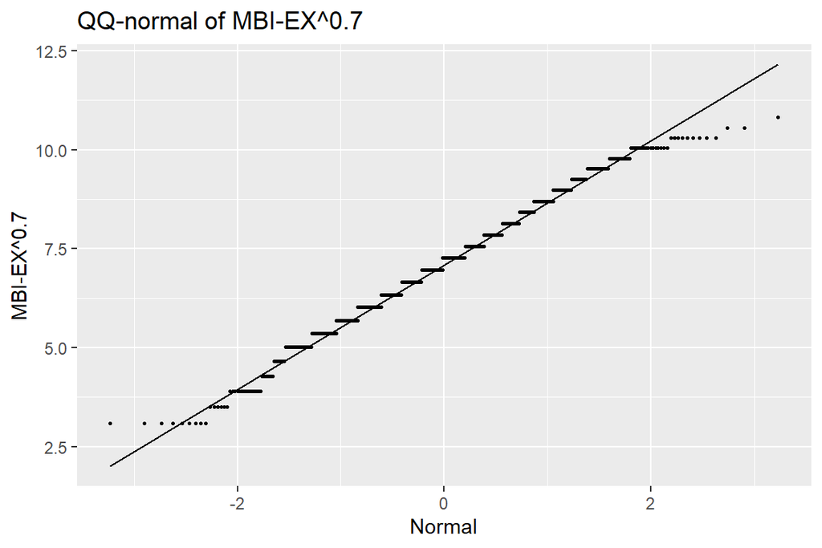

```r
ggplot(df_focus_tr) +
  geom_qq(aes(sample=mbi_ex_tr), size=0.5) +
  stat_qq_line(aes(sample=mbi_ex_tr)) +
  labs(x="Normal", y="MBI-EX^0.7", title="QQ-normal of MBI-EX^0.7")
```

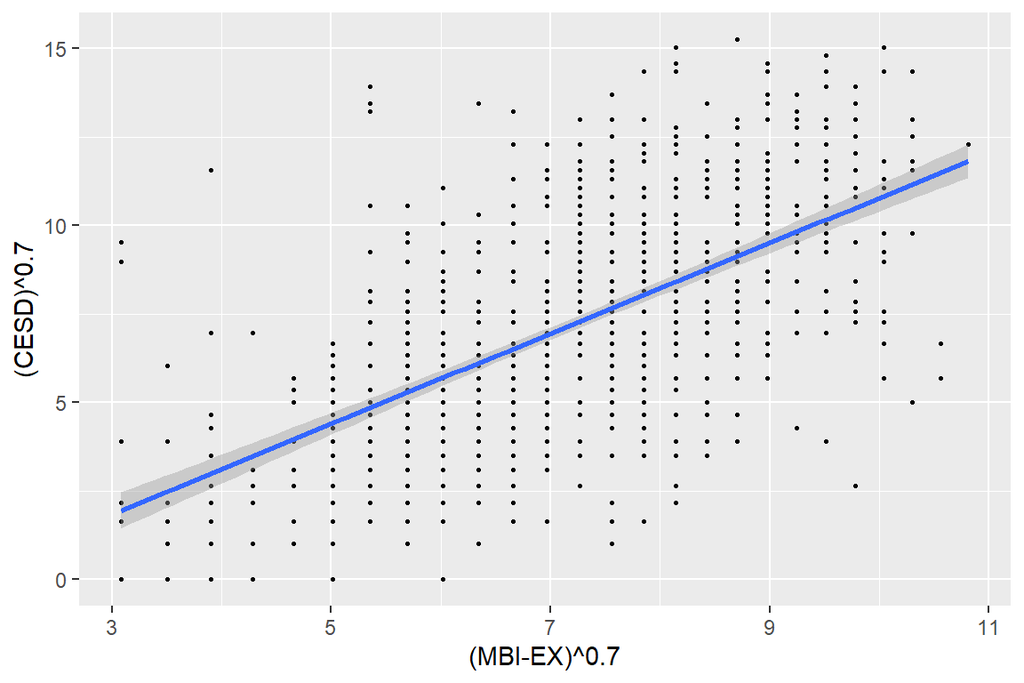

```r
stat_mbi_ex_tr <- stat.desc(df_focus_tr$mbi_ex_tr, norm=TRUE)
stat_cesd_tr <- stat.desc(df_focus_tr$cesd_tr, norm=TRUE)


df_focus_tr %>%
  ggplot(aes(x=mbi_ex_tr, y=cesd_tr)) +
  geom_point(size=0.5) +
  geom_smooth(formula = y ~ x, method=lm) +
  labs(x="(MBI-EX)^0.7", y="(CESD)^0.7")
```

```r
cortest_pearson <- cor.test(df_focus_tr$mbi_ex_tr, df_focus_tr$cesd_tr, method="pearson")
cortest_spearman <- cor.test(df_focus_tr$mbi_ex, df_focus_tr$cesd, method="spearman")
bootTau <- function(df, i) cor(df$mbi_ex[i], df$cesd[i],
                               method="spearman", use="complete.obs")
boot_spearman <- boot(df_focus, bootTau, 1000)
spearman_boot_ci <- boot.ci(boot_spearman)
```

*Instructions: Complete this assignment individually and submit online to the LEARN Dropbox as a* *PDF (max 2 pages)**. You may include any number of pages of appendices, which might include R output, statistics, or plots that don’t fit in to the report - just make sure that the report doesn’t rely on the appendices to make its points, as graders will at most skim or spot check the appendix. Also upload any source files, for example, and any .R or .Rmd files that you used. If you discussed problems with other students, please describe the nature of that discussion (e.g., on Team, in a study group). Remember, you can discuss approaches to problems with other people, but* *the work you submit must be your own.*

**Your assignment:** Choose two or more variables from the dataset: [Student Mental Health](https://www.kaggle.com/datasets/thedevastator/medical-student-mental-health) and analyze them using correlation. We will be looking at how you think about assumptions, conduct correlation analysis, and follow-up with conclusions and takeaways. As an added constraint, you must use either one example of using partial correlation (i.e., controlling for additional variables) or bootstrapped correlation (ideally with some rational for choosing bootstrapping). Beyond that, you can use as many or as few statistics, graphs, and tests as you need to discover something interesting.

**For your one report**, include the following sections:

1. Data: Provide a quick summary of your dataset and any data cleaning. Ensure that you explain why the variables selected would work for correlation. Clearly list any exclusions or transformations. Aim for 1/2 a page for the section.
2. Planning: Identify the variables that you will correlate and check assumptions of the model(s)/test(s) that you wish to carry out. Be explicit about what model(s)/test(s) you pick and why. This section will likely be a little bit shorter, probably about 1/2 of the page.
3. Analysis: Calculate correlation between your variables, graph it, interpret it, and write up the results. Use plots as appropriate. You may use additional analyses as needed. This will be the bulk of your report, likely 1/2-3/4 of a page.
4. Conclusion: Using the [APA style](https://owl.purdue.edu/owl/research_and_citation/using_research/writing_with_statistics/index.html), write up a conclusion for your analysis and what it might mean. Use plots as appropriate. This section likely be about 1/4 to 1/2 a page.

Good luck!

**Hint:** It’s important to read the documentation on the given dataset, this may give you a good starting point to approach your analysis.